# D213 Performance Assessment NLM2 Task 1 by Renzo Espinoza

# Part I: Research Question

## A1.

### Research Question:

Can we accurately predict the sentiment of a user's review as either positive or negative using past reviews from IMDb, Yelp, and Amazon?

# Part II: Data Preparation

```python
import pandas as pd
import numpy as np
import seaborn as sns
import matplotlib.pyplot as plt
from nltk import download
from nltk.corpus import stopwords
import re
from sklearn.model_selection import train_test_split
from tensorflow.keras.preprocessing.text import Tokenizer
from tensorflow.keras.preprocessing.sequence import pad_sequences
from tensorflow.keras import layers
from tensorflow.keras import optimizers
from tensorflow.keras.models import Sequential
from tensorflow.random import set_seed
from tensorflow.keras.callbacks import EarlyStopping
import keras_tuner as kt
```

```python
amazon_df = pd.read_csv('amazon_cells_labelled.txt', sep='\t', names=['review', 'score'])
amazon_df['source'] = 'Amazon'
```

```python
imdb_df = pd.read_csv('imdb_labelled.txt', sep='\t', names=['review', 'score'])
imdb_df['source'] = 'IMDb'
```

```python
yelp_df = pd.read_csv('yelp_labelled.txt', sep='\t', names=['review', 'score'])
yelp_df['source'] = 'Yelp'
```

```python
amazon_df.shape
```

```
(1000, 3)
```

```python
imdb_df.shape
```

```
(1000, 3)
```

A bit of manual data cleaning was needed for the imdb dataset, lines starting with quotation marks would cause several entries to become merged together

```python
yelp_df.shape
```

```
(1000, 3)
```

```python
df = pd.concat([amazon_df, imdb_df, yelp_df], ignore_index=True)
df
```

|  | review | score | source |
| --- | --- | --- | --- |
| 0 | So there is no way for me to plug it in here i... | 0 | Amazon |
| 1 | Good case, Excellent value. | 1 | Amazon |
| 2 | Great for the jawbone. | 1 | Amazon |
| 3 | Tied to charger for conversations lasting more... | 0 | Amazon |
| 4 | The mic is great. | 1 | Amazon |
| ... | ... | ... | ... |
| 2995 | I think food should have flavor and texture an... | 0 | Yelp |
| 2996 | Appetite instantly gone. | 0 | Yelp |
| 2997 | Overall I was not impressed and would not go b... | 0 | Yelp |
| 2998 | The whole experience was underwhelming, and I ... | 0 | Yelp |
| 2999 | Then, as if I hadn't wasted enough of my life ... | 0 | Yelp |

3000 rows × 3 columns

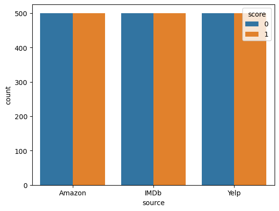

```python
sns.countplot(df, x='source', hue='score')
```

## B1 a.

```python
df.review = df.review.str.lower()
```

```python
characters = []

for review in df.review:
    for character in review:
        if character not in characters:
            characters.append(character)

print(characters)
```

```
['s', 'o', ' ', 't', 'h', 'e', 'r', 'i', 'n', 'w', 'a', 'y', 'f', 'm', 'p', 'l', 'u', 'g', 'b', 'c', 'v', '.', 'd', ',', 'x', 'j', '4', '5', '!', 'z', 'q', '+', '"', 'k', "'", '/', '7', '3', '6', '8', '0', '2', '?', '-', '1', ':', ')', '(', '&', '$', '*', ';', '%', '9', '#', '[', ']', '\x96', 'é', '…
```

```python
df.review.replace('[^A-Za-z ]+','',regex=True, inplace = True)
```

```python
characters = []

for review in df.review:
    for character in review:
        if character not in characters:
            characters.append(character)

print(characters)
```

```
['s', 'o', ' ', 't', 'h', 'e', 'r', 'i', 'n', 'w', 'a', 'y', 'f', 'm', 'p', 'l', 'u', 'g', 'b', 'c', 'v', 'd', 'x', 'j', 'z', 'q', 'k']
```

```python
stop = stopwords.words('english')

# Removes stop words from each row in 'review'
df.review = df.review.apply(lambda review: " ".join(word for word in review.split() if word not in stop))
```

```python
df
```

|  | review | score | source |
| --- | --- | --- | --- |
| 0 | way plug us unless go converter | 0 | Amazon |
| 1 | good case excellent value | 1 | Amazon |
| 2 | great jawbone | 1 | Amazon |
| 3 | tied charger conversations lasting minutes maj... | 0 | Amazon |
| 4 | mic great | 1 | Amazon |
| ... | ... | ... | ... |
| 2995 | think food flavor texture lacking | 0 | Yelp |
| 2996 | appetite instantly gone | 0 | Yelp |
| 2997 | overall impressed would go back | 0 | Yelp |
| 2998 | whole experience underwhelming think well go n... | 0 | Yelp |
| 2999 | hadnt wasted enough life poured salt wound dra... | 0 | Yelp |

3000 rows × 3 columns

```python
x_train, x_test, y_train, y_test = train_test_split(df.review,df.score, train_size=0.7, stratify=df.score, random_state=2)
x_val, x_test, y_val, y_test = train_test_split(x_test,y_test, test_size=0.5, stratify=y_test, random_state=2)
```

## B1 b.

```python
tokenizer = Tokenizer(oov_token = 'OOV')
tokenizer.fit_on_texts(x_train)
```

```python
vocab_size = len(tokenizer.word_index) + 1
print(f"Vocabulary size : {vocab_size}")
```

```
Vocabulary size : 4180
```

## B1 c.

The word embedding length should be the fourth root of the vocabulary size, according to: https://developers.googleblog.com/2017/11/introducing-tensorflow-feature-columns.html

```python
embedding_len = round(vocab_size ** .25)
print(f"Word embedding length: {embedding_len}")
```

```
Word embedding length: 8
```

## B1 d.

# According to Caner Kilinc, the maximum sequence length should be set to the max amount of words in a sentence.

https://medium.com/@canerkilinc/padding-for-nlp-7dd8598c916a

```python
word_amount = []

for sentence in df.review:
    word_amount.append(len(sentence.split(' ')))

max_sequence_len = np.max(word_amount)
print(f"Max sequence length: {max_sequence_len}")
```

```
Max sequence length: 41
```

## B2

```python
tokenizer = Tokenizer(oov_token = 'OOV')
tokenizer.fit_on_texts(x_train)

sequences_train = tokenizer.texts_to_sequences(x_train)
sequences_test = tokenizer.texts_to_sequences(x_test)
sequences_val = tokenizer.texts_to_sequences(x_val)
```

```python
sequences_train[0]
```

```
[101, 1588, 101]
```

## B3

```python
padding_type = trunc_type = 'post'

padded_train = pad_sequences(sequences_train, maxlen=max_sequence_len, padding=padding_type, truncating=trunc_type)

padded_test = pad_sequences(sequences_test, maxlen=max_sequence_len, padding=padding_type, truncating=trunc_type)

padded_val = pad_sequences(sequences_val, maxlen=max_sequence_len, padding=padding_type, truncating=trunc_type)
```

```python
padded_train[0]
```

```
array([ 101, 1588,  101,    0,    0,    0,    0,    0,    0,    0,    0,
          0,    0,    0,    0,    0,    0,    0,    0,    0,    0,    0,
          0,    0,    0,    0,    0,    0,    0,    0,    0,    0,    0,
          0,    0,    0,    0,    0,    0,    0,    0], dtype=int32)
```

The high sequence length value results in sequences like this, which contain a large amount of padding tokens.This can negatively affect the RNN's performance because these 0's can overload the RNN cell's short-term memory and cause it to forget the tokens at the start of the sequence. To solve this I will add masking to the embedding layer.

## B4

The final dense layer of the network will use sigmoid as its activation function and have 2 categories of sentiment, 0 for negative and 1 for positive

## B6

```python
df.to_csv('PA2_cleaned_data.csv')
```

# Part III: Network Architecture

## C1

```python
def build_model(hp):
    n_hidden = hp.Int("n_hidden", min_value=0, max_value=8)
    n_neurons = hp.Int("n_neurons", min_value=16, max_value=256)
    learning_rate = hp.Float("learning_rate", min_value=1e-4, max_value=1e-2, sampling="log")
    optimizer = optimizers.Nadam(learning_rate=learning_rate)

    model = Sequential()
    model.add(layers.Embedding(vocab_size, embedding_len, mask_zero=True))
    model.add(layers.GRU(n_neurons))
    for _ in range(n_hidden):
        model.add(layers.Dense(n_neurons, activation="relu"))
    model.add(layers.Dense(1, activation="sigmoid"))
    model.compile(loss="binary_crossentropy", optimizer=optimizer, metrics=["accuracy"])
    return model
```

```python
early_stopping_cb = EarlyStopping(patience=2)
random_search_tuner = kt.Hyperband(
    build_model, objective="val_accuracy", overwrite=True,
    directory="hp_search_results", project_name="d213_task2", seed=2,
    max_epochs=10, factor=3, hyperband_iterations=2)

random_search_tuner.search(padded_train, y_train, epochs=10,
                           validation_data=(padded_val, y_val),
                          callbacks=[early_stopping_cb])
```

```
Trial 60 Complete [00h 00m 18s]
val_accuracy: 0.7488889098167419

Best val_accuracy So Far: 0.8022222518920898
Total elapsed time: 00h 26m 31s
INFO:tensorflow:Oracle triggered exit
```

```python
best_trial = random_search_tuner.oracle.get_best_trials(num_trials=1)[0]
best_trial.summary()
```

```
Trial summary
Hyperparameters:
n_hidden: 4
n_neurons: 74
learning_rate: 0.00905127409782462
tuner/epochs: 4
tuner/initial_epoch: 0
tuner/bracket: 1
tuner/round: 0
Score: 0.8022222518920898
```

```python
best_model = random_search_tuner.get_best_models(num_models=1)[0]
best_model.summary()
```

```
Model: "sequential"
_________________________________________________________________
 Layer (type)                Output Shape              Param #
=================================================================
 embedding (Embedding)       (None, None, 8)           33440

 gru (GRU)                   (None, 74)                18648

 dense (Dense)               (None, 74)                5550

 dense_1 (Dense)             (None, 74)                5550

 dense_2 (Dense)             (None, 74)                5550

 dense_3 (Dense)             (None, 74)                5550

 dense_4 (Dense)             (None, 1)                 75

=================================================================
Total params: 74,363
Trainable params: 74,363
Non-trainable params: 0
_________________________________________________________________
```

## C3 f.

```python
train_acc = best_trial.metrics.get_history('accuracy')[0].value[0]
train_loss = best_trial.metrics.get_history('loss')[0].value[0]

val_acc = best_trial.metrics.get_history('val_accuracy')[0].value[0]
val_loss = best_trial.metrics.get_history('val_loss')[0].value[0]
```

```python
print(f"Train loss: {train_loss} / Train accuracy: {train_acc}")
print()
print(f"Validatoin loss: {val_loss} / Validation accuracy: {val_acc}")
print()
score = best_model.evaluate(padded_test, y_test, verbose=0)
print(f"Test loss: {score[0]} / Test accuracy: {score[1]}")
```

```
Train loss: 0.05877332016825676 / Train accuracy: 0.9814285635948181

Validatoin loss: 0.6778173446655273 / Validation accuracy: 0.8022222518920898

Test loss: 0.7015459537506104 / Test accuracy: 0.8066666722297668
```

## D1

```python
new_model = Sequential().from_config(best_model.get_config())
new_model.compile(loss="binary_crossentropy", optimizer=best_model.optimizer, metrics=["accuracy"])
```

```python
history = new_model.fit(padded_train, y_train, epochs=10,
                           validation_data=(padded_val, y_val), callbacks=[early_stopping_cb])
```

## D2

```python
acc_history = history.history['accuracy']
train_loss_history = history.history['loss']

val_history = history.history['val_accuracy']
val_loss_history = history.history['val_loss']
```

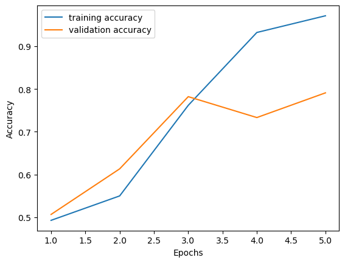

```python
epochs = list(range(1,len(acc_history)+1))
plt.plot(epochs, acc_history, label = "training accuracy")
plt.plot(epochs, val_history, label = "validation accuracy")
plt.xlabel('Epochs')
plt.ylabel('Accuracy')
plt.legend()
plt.show()
```

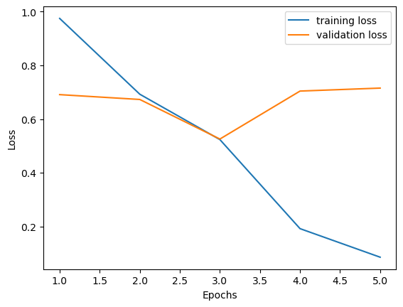

```python
epochs = list(range(1,len(acc_history)+1))
plt.plot(epochs, train_loss_history, label = "training loss")
plt.plot(epochs, val_loss_history, label = "validation loss")
plt.xlabel('Epochs')
plt.ylabel('Loss')
plt.legend()
plt.show()
```

# Part V: Summary and Recommendations

## E

```python
best_model.save('SentimentAnalysisModel.h5')
```